# Canine Skin Microbiome: 16S Change-Point Analysis

Spencer Toth

2026-09-22

**Purpose:** Investigate how canine skin microbial composition changes in result of disturbance (surgery).

**Null Hypothesis:** No change-point in bray-curtis dissimilarity between paired control and surgical sites of dogs before surgery.

**Description:** Each dog has its own control prior to surgery as well as a control site that did not undergo surgery. This allowed us to model how within-dog control–surgical dissimilarity changed with number of days since surgery.

**References:**

- Longitudinal profiling of the microbiome at four body sites reveals core stability and individualized dynamics during health and disease (Cell Host Microbe - April 2025) https://pmc.ncbi.nlm.nih.gov/articles/PMC11022754/
- Metagenomic characterisation of canine skin reveals a core healthy skin microbiome (Nature - August 2024) https://www.nature.com/articles/s41598-024-63999-5
- Cutaneous Microbiome Profiles Following Chlorhexidine Treatment in a 72-Hour Daily Follow-Up Paired Design: a Pilot Study (ASM - June 2022) https://journals.asm.org/doi/full/10.1128/spectrum.01753-21

# Load R packages

```r
library(knitr)
library(FSA)
library(tidyverse)
library(vegan)
library(phyloseq)
library(ggplot2)
library(ggtree)
library(scales)
library(RColorBrewer)
library(segmented)
library(stringr)
library(pairwiseAdonis)
library(ggpubr)
library(changepoint)
library(dplyr)
library(lme4)
library(emmeans)
library(nortest)
library(mcp)
library(purrr)
library(kableExtra)
library(forcats)
```

# Generate Paired-Only

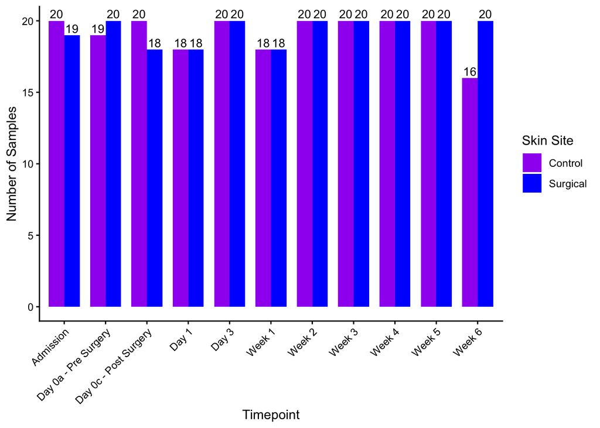

```r
ps_1 <- readRDS("../01_input_files/phyloseq/ps_1.rds")
metadata <- as(sample_data(ps_1), "data.frame")

# Set timepoint order
day_levels <- c(
  "Admission",
  "Day 0a - Pre Surgery",
  "Day 0c - Post Surgery",
  "Day 1",
  "Day 3",
  "Week 1",
  "Week 2",
  "Week 3",
  "Week 4",
  "Week 5",
  "Week 6"
)
metadata$Day_Order <- factor(metadata$Day_Order, levels = day_levels)
metadata$Sample_Site <- factor(metadata$Sample_Site, levels = c("Control", "Surgical"))

#Count skin samples across timepoints
count_df <- metadata %>%
  dplyr::select(Day_Order, Sample_Site, Sample_Unique) %>%
  distinct() %>%
  group_by(Day_Order, Sample_Site) %>%
  summarise(n = n(), .groups = "drop")


count_df$Day_Order <- factor(count_df$Day_Order, levels = day_levels)
count_df$Sample_Site <- factor(count_df$Sample_Site, levels = c("Control", "Surgical"))

p <- ggplot(count_df, aes(x = Day_Order, y = n, fill = Sample_Site)) +
  geom_col(position = position_dodge(width = 0.75), width = 0.75) +
  geom_text(
    aes(label = n),
    position = position_dodge(width = 0.75),
    vjust = -0.3,
    size = 3.5
  ) +
  scale_fill_manual(values = c("Control" = "purple", "Surgical" = "blue")) +
  labs(
    x = "Timepoint",
    y = "Number of Samples",
    fill = "Skin Site"
  ) +
  theme_classic() +
  theme(
    axis.text.x = element_text(angle = 45, hjust = 1),
    legend.position = "right"
  )

print(p)
```

```r
# Check which dogs are missing samples (either control or surgical) at each timepoint
missing_sample_unique <- metadata %>%
  group_by(Individual, Day_Order) %>%
  summarise(
    site_absent = if (all(c("Control", "Surgical") %in% Sample_Site)) NA_character_
                  else paste(setdiff(c("Control", "Surgical"), unique(Sample_Site)), collapse = ", "),
    Sample_Unique = paste(sort(unique(Sample_Unique)), collapse = ", "),
    n_sites = n_distinct(Sample_Site),
    .groups = "drop"
  ) %>%
  filter(n_sites < 2) %>%
  dplyr::select(Individual, Day_Order, site_absent, Sample_Unique) %>%
  arrange(Individual, Day_Order)

print(missing_sample_unique)
```

```
## # A tibble: 10 × 4
##    Individual Day_Order             site_absent Sample_Unique
##    <chr>      <fct>                 <chr>       <chr>
##  1 CH003      Day 0c - Post Surgery Surgical    3PostC
##  2 CH005      Admission             Surgical    5AdC
##  3 CH008      Week 6                Control     8D42S
##  4 CH011      Week 1                Surgical    11D7C
##  5 CH011      Week 6                Control     11D42S
##  6 CH012      Week 1                Control     12D7S
##  7 CH013      Week 6                Control     13D42S
##  8 CH014      Week 6                Control     14D42S
##  9 CH016      Day 0a - Pre Surgery  Control     16PreS
## 10 CH021      Day 0c - Post Surgery Surgical    21PostC
```

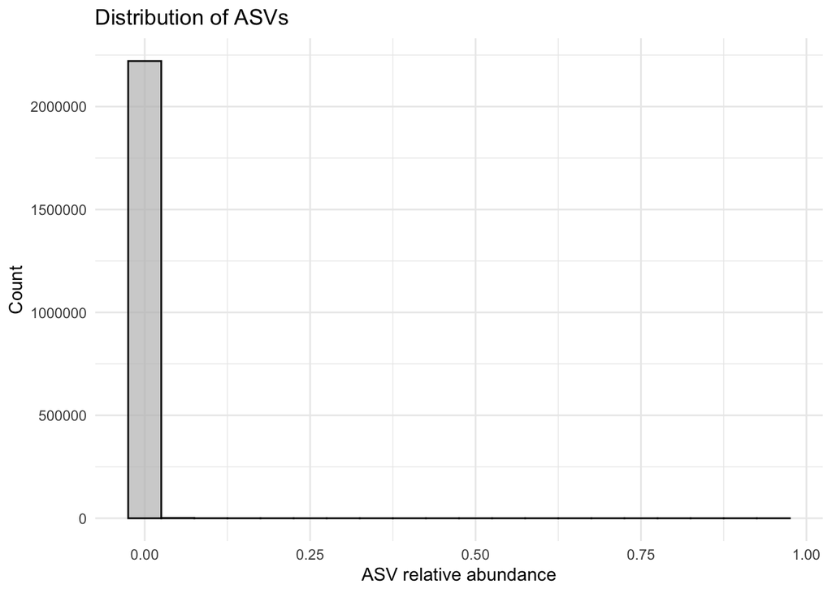

```r
# Keep only samples that have control and surgical at each Day_Order
paired_groups <- metadata %>%
  group_by(Individual, Day_Order) %>%
  summarize(n_sites = n_distinct(Sample_Site), .groups = "drop") %>%
  filter(n_sites == 2) %>%
  transmute(Individual, Day_Order)
paired_sample_data <- metadata %>%
  inner_join(paired_groups, by = c("Individual", "Day_Order"))


# Prune phyloseq object so it only contains these remaining samples
ps_2 <- prune_samples(paired_sample_data$SampleID, ps_1)



out_dir <- "../01_input_files/phyloseq"
dir.create(out_dir, recursive = TRUE, showWarnings = FALSE)
saveRDS(ps_2, file = file.path(out_dir, "ps_2.rds"))


# Normalize read counts by dividing by total read count per sample (relative abundance)
ps_rel_2 <- transform_sample_counts(ps_2, function(x) x / sum(x))
rel_abundance_vector <- as.numeric(
  as(phyloseq::otu_table(ps_rel_2), "matrix")
)

x <- rel_abundance_vector
# Plot Distribution of Transformed Bray-Curtis Distances
histogram_distances <- ggplot(data = data.frame(x), aes(x = x)) +
  geom_histogram(binwidth = 0.05, fill = "gray", color = "black", alpha = 0.7) +
  theme_minimal() +
  labs(
    title = "Distribution of ASVs",
    x = "ASV relative abundance",
    y = "Count"
  )

print(histogram_distances)
```

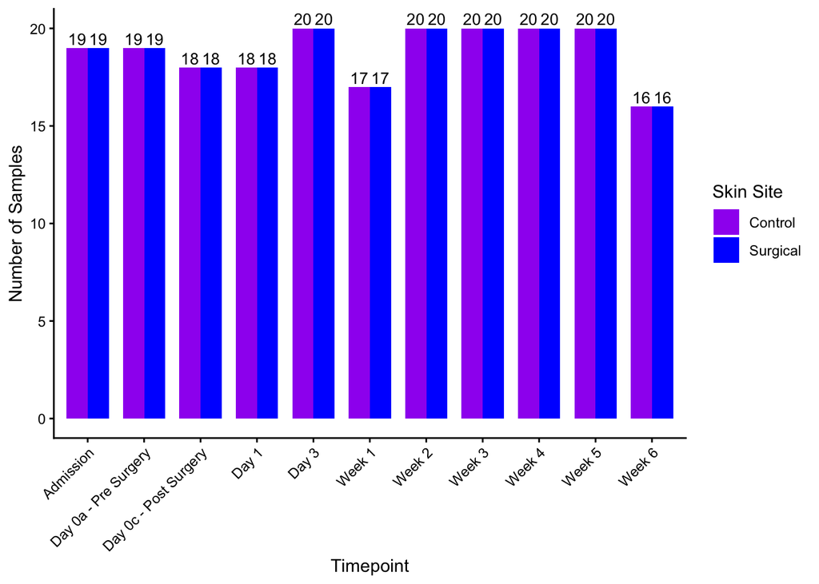

```r
# Count unique samples by Day_Order and Sample_Site
count_df <- paired_sample_data %>%
  dplyr::select(Day_Order, Sample_Site, Sample_Unique) %>%
  distinct() %>%
  group_by(Day_Order, Sample_Site) %>%
  summarise(n = n(), .groups = "drop")


count_df$Day_Order <- factor(count_df$Day_Order, levels = day_levels)


count_df$Sample_Site <- factor(count_df$Sample_Site, levels = c("Control", "Surgical"))

# Updated after removing dog-timepoint samples with only one site
p <- ggplot(count_df, aes(x = Day_Order, y = n, fill = Sample_Site)) +
  geom_col(position = position_dodge(width = 0.75), width = 0.75) +
  geom_text(
    aes(label = n),
    position = position_dodge(width = 0.75),
    vjust = -0.3,
    size = 3.5
  ) +
  scale_fill_manual(values = c("Control" = "purple", "Surgical" = "blue")) +
  labs(
    x = "Timepoint",
    y = "Number of Samples",
    fill = "Skin Site"
  ) +
  theme_classic() +
  theme(
    axis.text.x = element_text(angle = 45, hjust = 1),
    legend.position = "right"
  )

print(p)
```

```r
paired_sample_data$Sample_Site <- factor(paired_sample_data$Sample_Site)
paired_sample_data$Dog_ID <- factor(paired_sample_data$Dog_ID)
paired_sample_data$Sample_Plate <- factor(paired_sample_data$Sample_Plate)
paired_sample_data$Collection_Day <- as.numeric(paired_sample_data$Collection_Day)


dog_library_table <- with(
  paired_sample_data,
  table(Individual, Sample_Plate)
)
dog_library_table <- rbind(
  dog_library_table,
  Total = colSums(dog_library_table)
)
dog_library_table
```

```
##       CHLib1 CHLib2 CHLib3 CHLib4
## CH001     22      0      0      0
## CH003      0     18      0      0
## CH005     20      0      0      0
## CH006     22      0      0      0
## CH008     20      0      0      0
## CH009      0      0     22      0
## CH011      0     18      0      0
## CH012     20      0      0      0
## CH013      0     20      0      0
## CH014      0     20      0      0
## CH016      0     20      0      0
## CH017      0      0      0     22
## CH018      0      0      0     20
## CH019      0      0      0     22
## CH020      0      0     22      0
## CH021      0      0      0     20
## CH022      0      0     22      0
## CH023      0      0      0     20
## CH024      0      0     22      0
## CH025      0      0     22      0
## Total    104     96    110    104
```

```r
out_table <- paste0(out_dir, "/total_paired_samples_by_individual.png")

dog_library_table_bold <- dog_library_table
dog_library_table_bold[dog_library_table_bold != 0] <- paste0(
  "<b>", dog_library_table_bold[dog_library_table_bold != 0], "</b>"
)


paste0("Number of dogs: ", length(unique(paired_sample_data$Dog_ID)))
```

```
## [1] "Number of dogs: 20"
```

```r
paste0("Number of samples: ", length(unique(paired_sample_data$Sample)))
```

```
## [1] "Number of samples: 414"
```

```r
kbl_obj <- kable(
  dog_library_table_bold,
  caption = "Dog Paired-Sample Count per Sequencing Run",
  align = "c",
  escape = FALSE,
  format = "html"
) %>%
  kable_styling(
    bootstrap_options = c("striped", "hover", "condensed", "bordered"),
    full_width = FALSE
  ) %>%
  column_spec(1:ncol(dog_library_table_bold), color = "black") %>%
  row_spec(
    nrow(dog_library_table_bold),
    bold = TRUE,
    color = "black",
    background = "#f2f2f2"
  )

kbl_obj
```

Dog Paired-Sample Count per Sequencing Run

|  | CHLib1 | CHLib2 | CHLib3 | CHLib4 |
| --- | --- | --- | --- | --- |
| CH001 | **22** | 0 | 0 | 0 |
| CH003 | 0 | **18** | 0 | 0 |
| CH005 | **20** | 0 | 0 | 0 |
| CH006 | **22** | 0 | 0 | 0 |
| CH008 | **20** | 0 | 0 | 0 |
| CH009 | 0 | 0 | **22** | 0 |
| CH011 | 0 | **18** | 0 | 0 |
| CH012 | **20** | 0 | 0 | 0 |
| CH013 | 0 | **20** | 0 | 0 |
| CH014 | 0 | **20** | 0 | 0 |
| CH016 | 0 | **20** | 0 | 0 |
| CH017 | 0 | 0 | 0 | **22** |
| CH018 | 0 | 0 | 0 | **20** |
| CH019 | 0 | 0 | 0 | **22** |
| CH020 | 0 | 0 | **22** | 0 |
| CH021 | 0 | 0 | 0 | **20** |
| CH022 | 0 | 0 | **22** | 0 |
| CH023 | 0 | 0 | 0 | **20** |
| CH024 | 0 | 0 | **22** | 0 |
| CH025 | 0 | 0 | **22** | 0 |
| Total | **104** | **96** | **110** | **104** |

## Total Reads + ASVs per Individual

```r
out_dir <- "../02_output_files/images"

# Get reads and metadata per sample
reads_per_sample <- sample_sums(ps_2)
paired_sample_data <- as(sample_data(ps_2), "data.frame")

sample_names_ps <- sample_names(ps_2)

# Ensure sample order matches
if (!all(sample_names_ps == rownames(paired_sample_data))) {
  paired_sample_data <- paired_sample_data[sample_names_ps, ]
}

# Create dataframe with sample-level stats
df <- data.frame(
  sample = sample_names_ps,
  total_reads = reads_per_sample,
  Sample_Plate = paired_sample_data$Sample_Plate,
  Individual = paired_sample_data$Individual,
  stringsAsFactors = FALSE
)

mean_reads <- mean(df$total_reads)
min_reads  <- min(df$total_reads)
max_reads  <- max(df$total_reads)

mean_reads
```

```
## [1] 35079.49
```

```r
min_reads
```

```
## [1] 2385
```

```r
max_reads
```

```
## [1] 132591
```

```r
# Calculate total reads and ASVs per sample and add to metadata
otu <- otu_table(ps_2)
if (taxa_are_rows(otu)) {
  total_asvs <- colSums(otu > 0)
} else {
  total_asvs <- rowSums(otu > 0)
}

total_reads <- sample_sums(ps_2)

paired_sample_data$total_asv <- total_asvs
paired_sample_data$total_reads <- total_reads

sample_data(ps_2) <- sample_data(paired_sample_data)

paired_sample_data <- paired_sample_data %>%
  arrange(Surgery_Type, Individual) %>%
  mutate(Individual = factor(Individual, levels = unique(Individual)))

my_cols <- colorRampPalette(brewer.pal(8, "Dark2"))(20)

# Aggregate reads and ASVs per Individual
by_ind <- aggregate(
  cbind(total_reads, total_asv) ~ Individual + Sample_Plate,
  data = paired_sample_data,
  FUN = sum
)

print(by_ind)
```

```
##    Individual Sample_Plate total_reads total_asv
## 1       CH001       CHLib1      373702     10305
## 2       CH005       CHLib1      443841     10770
## 3       CH006       CHLib1      697696      9305
## 4       CH008       CHLib1      612503      9780
## 5       CH012       CHLib1      791209      7611
## 6       CH003       CHLib2      351990      6826
## 7       CH011       CHLib2      444107      7404
## 8       CH013       CHLib2      988197      9566
## 9       CH014       CHLib2     1201843     12078
## 10      CH016       CHLib2      980018     11633
## 11      CH009       CHLib3      756144     17000
## 12      CH020       CHLib3      315145     30211
## 13      CH022       CHLib3      471323     34908
## 14      CH024       CHLib3      611668     33923
## 15      CH025       CHLib3     1178682     21048
## 16      CH017       CHLib4      418394     14906
## 17      CH018       CHLib4      917796     17297
## 18      CH019       CHLib4      886238     32838
## 19      CH021       CHLib4     1068287     15279
## 20      CH023       CHLib4     1014124     11823
```

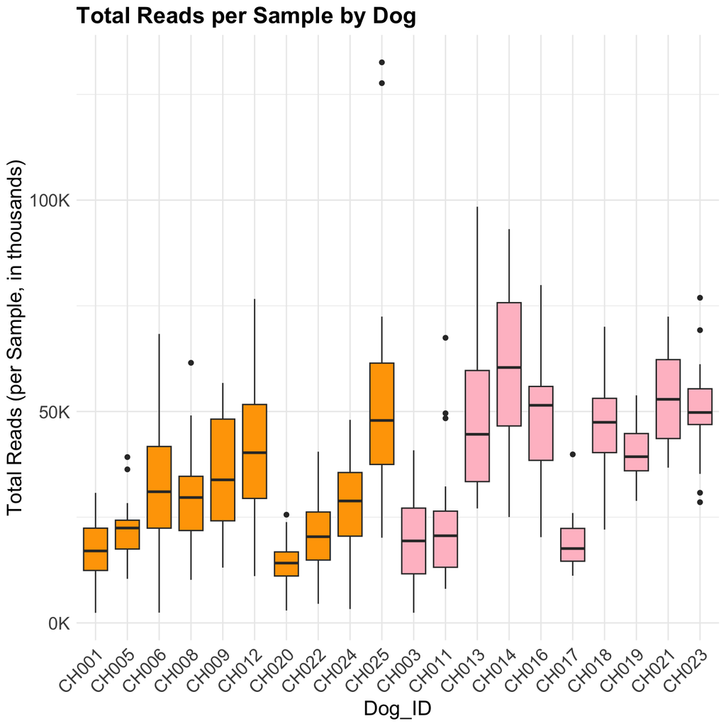

```r
# Boxplot for total reads by Individual (each point = one sample)
p_reads <- ggplot(paired_sample_data, aes(x = Individual, y = total_reads, fill = Surgery_Type)) +
  geom_boxplot()  +
  scale_fill_manual(values = c(
    "Abdomen" = "orange",
    "Stifle" = "pink"
  )) +
  scale_y_continuous(
    labels = function(x) paste0(x / 1000, "K"),
    name = "Total Reads (per Sample, in thousands)"
  ) +
  labs(
    title = "Total Reads per Sample by Dog",
    x = "Dog_ID"
  ) +
  theme_minimal()+
  theme(
    axis.text.x = element_text(angle = 45, hjust = 1, size = 14),
    axis.text.y = element_text(size = 14),
    axis.title.x = element_text(size = 16),
    axis.title.y = element_text(size = 16),
    plot.title = element_text(size = 18, face = "bold"),
    legend.position = "none"
  )

p_reads
```

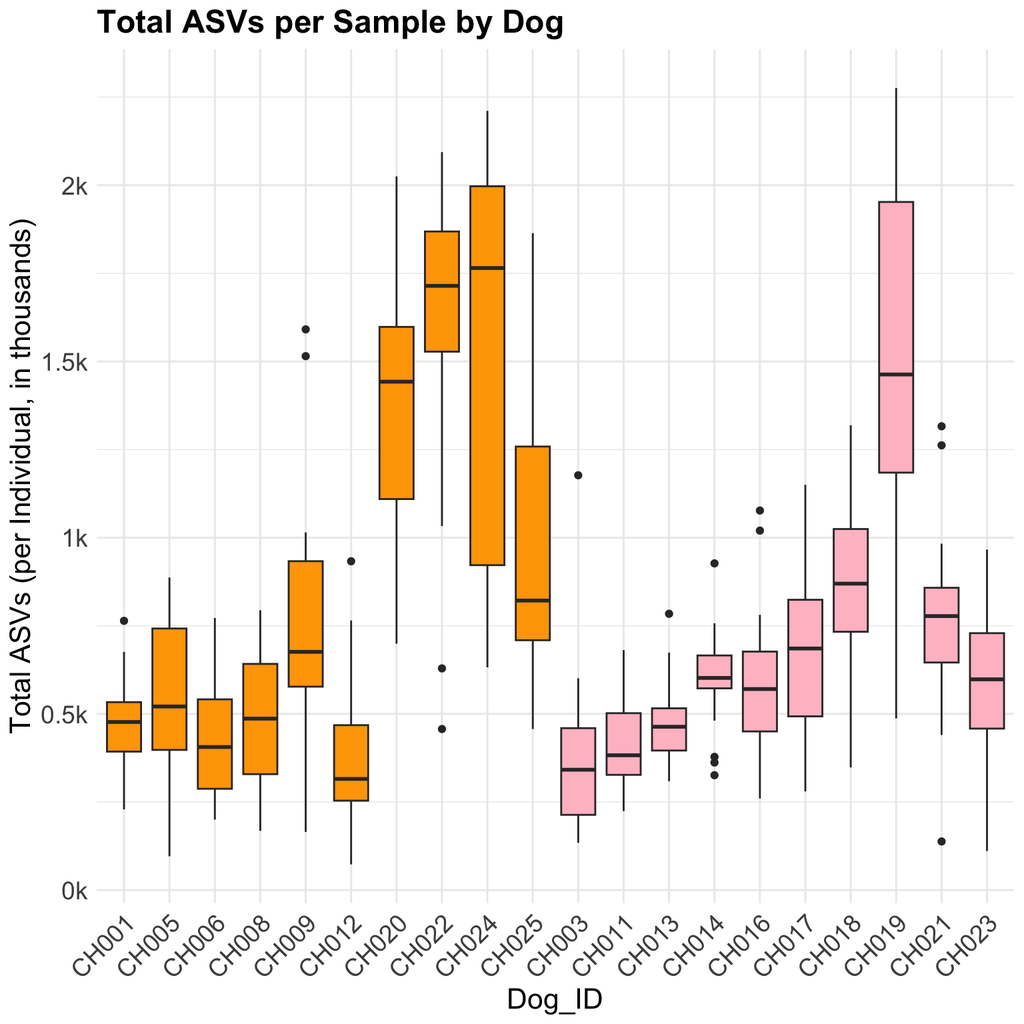

```r
out_reads <- paste0(out_dir, "/total_reads_by_individual_paired.png")
ggplot2::ggsave(out_reads, p_reads, width = 8, height = 6)


# Boxplot for total ASVs by Individual (each point = one sample)
p_asv <- ggplot(paired_sample_data, aes(x = Individual, y = total_asv, fill = Surgery_Type)) +
  geom_boxplot() +
  scale_fill_manual(values = c(
    "Abdomen" = "orange",
    "Stifle" = "pink"
  )) +
  scale_y_continuous(
    labels = function(x) paste0(x / 1000, "k"),
    name = "Total ASVs (per Individual, in thousands)"
  ) +
  labs(
    title = "Total ASVs per Sample by Dog",
    x = "Dog_ID"
  ) +
  theme_minimal()+
  theme(
    axis.text.x = element_text(angle = 45, hjust = 1, size = 14),
    axis.text.y = element_text(size = 14),
    axis.title.x = element_text(size = 16),
    axis.title.y = element_text(size = 16),
    plot.title = element_text(size = 18, face = "bold"),
    legend.position = "none"
  )
p_asv
```

```r
out_asv <- paste0(out_dir, "/total_asvs_by_individual_paired.png")
ggplot2::ggsave(out_asv, p_asv, width = 8, height = 6)
```

# Shannon Alpha-Diversity

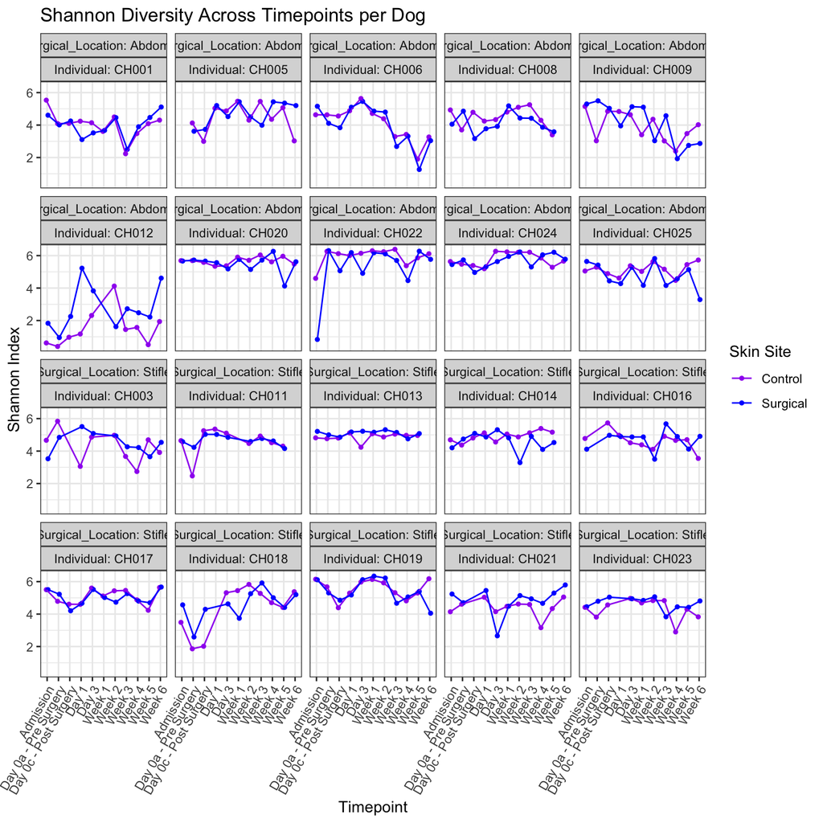

```r
alphadiv_plot_data <- estimate_richness(ps_2, measures = "Shannon") %>%
  rownames_to_column(var = "SampleID") %>%
  left_join(as.data.frame(sample_data(ps_2)), by = "SampleID") %>%
  group_by(Individual) %>%
  mutate(Surgical_Location = Sample_Location[Sample_Site == "Surgical"][1]) %>%
  ungroup() %>%
  mutate(Surgical_Location = factor(Surgical_Location)) %>%
  arrange(Surgical_Location, Individual)
ggplot(alphadiv_plot_data, aes(x = factor(Day_Order), y = Shannon, color = Sample_Site, group = Sample_Site)) +
  geom_point(size = 1, position = position_dodge(width = 0.3)) +
  geom_line(position = position_dodge(width = 0.3)) +
  facet_wrap(
    Surgical_Location ~ Individual,
    labeller = label_both
  ) +
  scale_color_manual(values = c("Control" = "purple", "Surgical" = "blue")) +
  theme_bw() +
  labs(
    title = "Shannon Diversity Across Timepoints per Dog",
    x = "Timepoint",
    y = "Shannon Index",
    color = "Skin Site"
  ) +
  theme(axis.text.x = element_text(angle = 60, hjust = 1))
```

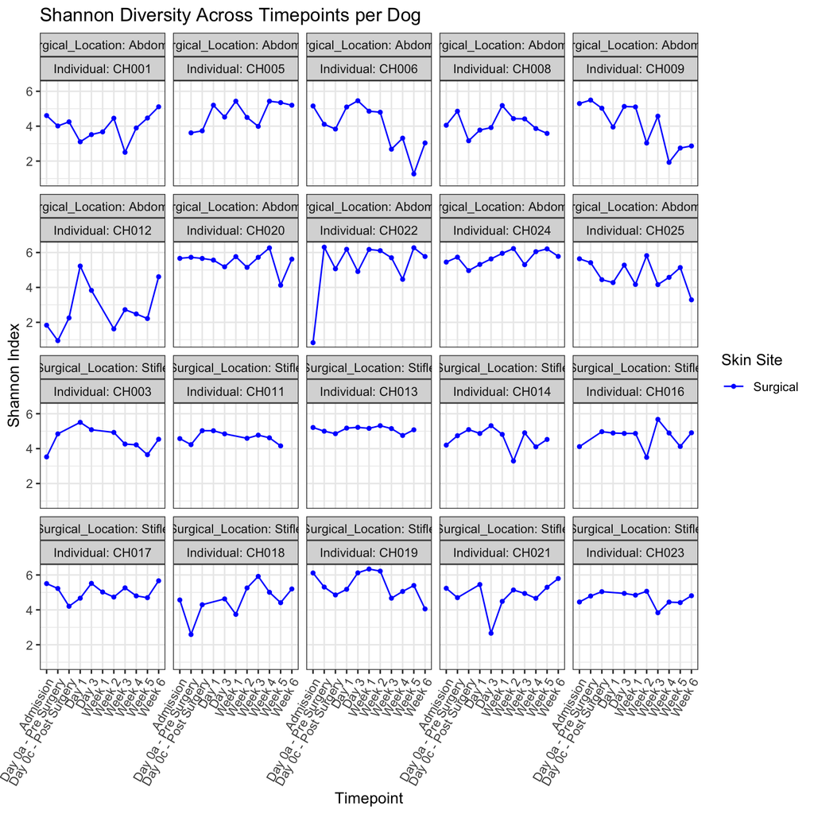

```r
alphadiv_plot_data_surg <- estimate_richness(ps_2, measures = "Shannon") %>%
  filter(sample_data(ps_2)$Sample_Site == "Surgical")  %>%
  rownames_to_column(var = "SampleID") %>%
  left_join(as.data.frame(sample_data(ps_2)), by = "SampleID") %>%
  group_by(Individual) %>%
  mutate(Surgical_Location = Sample_Location[Sample_Site == "Surgical"][1]) %>%
  ungroup() %>%
  mutate(Surgical_Location = factor(Surgical_Location)) %>%
  arrange(Surgical_Location, Individual)
ggplot(alphadiv_plot_data_surg, aes(x = factor(Day_Order), y = Shannon, color = Sample_Site, group = Sample_Site)) +
  geom_point(size = 1, position = position_dodge(width = 0.3)) +
  geom_line(position = position_dodge(width = 0.3)) +
  facet_wrap(
    Surgical_Location ~ Individual,
    labeller = label_both
  ) +
  scale_color_manual(values = c("Surgical" = "blue")) +
  theme_bw() +
  labs(
    title = "Shannon Diversity Across Timepoints per Dog",
    x = "Timepoint",
    y = "Shannon Index",
    color = "Skin Site"
  ) +
  theme(axis.text.x = element_text(angle = 60, hjust = 1))
```

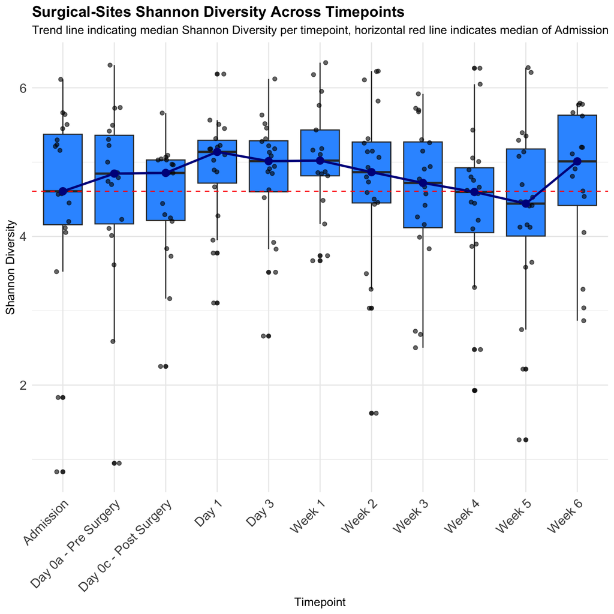

```r
alphadiv_plot_surgical <- estimate_richness(ps_2, measures = "Shannon") %>%
  rownames_to_column(var = "SampleID") %>%
  left_join(as.data.frame(sample_data(ps_2)), by = "SampleID") %>%
  filter(Sample_Site == "Surgical") %>%
  mutate(Sample_Location = factor(Sample_Location)) %>%
  arrange(Sample_Location, Individual)

alphadiv_plot_surgical_median <- alphadiv_plot_surgical %>%
  group_by(Day_Order) %>%
  summarise(median_Shannon = median(Shannon, na.rm = TRUE), .groups = "drop")


ggplot(alphadiv_plot_surgical, aes(x = Day_Order, y = Shannon)) +
  geom_boxplot(fill = "#3399FF") +
  geom_jitter(width = 0.15, alpha = 0.6, color = "black") +

  geom_hline(yintercept = alphadiv_plot_surgical_median$median_Shannon[1], linetype = "dashed", color="red") +
  geom_point(data = alphadiv_plot_surgical_median, aes(x = Day_Order, y = median_Shannon),
             inherit.aes = FALSE, color = "darkblue", size = 3) +
  geom_line(data = alphadiv_plot_surgical_median, aes(x = Day_Order, y = median_Shannon, group = 1),
            inherit.aes = FALSE, color = "darkblue", linewidth = 1) +
  labs(
    title = "Surgical-Sites Shannon Diversity Across Timepoints",
    subtitle = "Trend line indicating median Shannon Diversity per timepoint, horizontal red line indicates median of Admission",
    x = "Timepoint",
    y = "Shannon Diversity"
  ) +
  theme_minimal() +
  theme(
    plot.title = element_text(size = 14, face = "bold"),
    axis.text.x = element_text(size = 12, angle = 45, hjust = 1),
    axis.text.y = element_text(size = 12)
  )
```

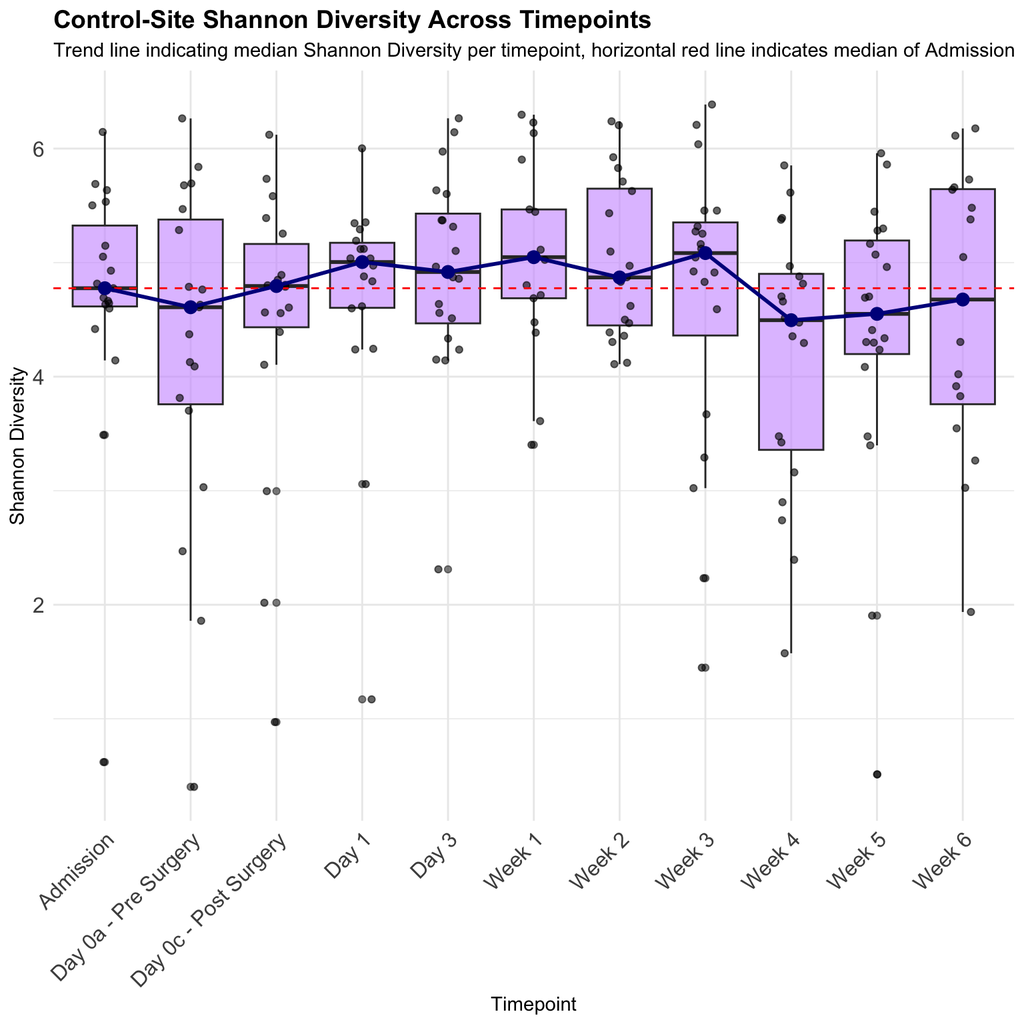

```r
alphadiv_plot_control <- estimate_richness(ps_2, measures = "Shannon") %>%
  rownames_to_column(var = "SampleID") %>%
  left_join(as.data.frame(sample_data(ps_2)), by = "SampleID") %>%
  filter(Sample_Site == "Control") %>%
  mutate(Sample_Location = factor(Sample_Location)) %>%
  arrange(Sample_Location, Individual)

alphadiv_plot_control_median <- alphadiv_plot_control %>%
  group_by(Day_Order) %>%
  summarise(median_Shannon = median(Shannon, na.rm = TRUE), .groups = "drop")


ggplot(alphadiv_plot_control, aes(x = Day_Order, y = Shannon)) +
  geom_boxplot(fill = "#CC99FF", alpha = 0.6) +
  geom_jitter(width = 0.15, alpha = 0.6, color = "black") +

  geom_hline(yintercept = alphadiv_plot_control_median$median_Shannon[1], linetype = "dashed", color="red") +
  geom_point(data = alphadiv_plot_control_median, aes(x = Day_Order, y = median_Shannon),
             inherit.aes = FALSE, color = "darkblue", size = 3) +
  geom_line(data = alphadiv_plot_control_median, aes(x = Day_Order, y = median_Shannon, group = 1),
            inherit.aes = FALSE, color = "darkblue", linewidth = 1) +
  labs(
    title = "Control-Site Shannon Diversity Across Timepoints",
    subtitle = "Trend line indicating median Shannon Diversity per timepoint, horizontal red line indicates median of Admission",
    x = "Timepoint",
    y = "Shannon Diversity"
  ) +
  theme_minimal() +
  theme(
    plot.title = element_text(size = 14, face = "bold"),
    axis.text.x = element_text(size = 12, angle = 45, hjust = 1),
    axis.text.y = element_text(size = 12)
  )
```

# Bray-Curtis (BC) Dissimilarity

```r
# Generate bray-curtis distance matrix using ASV relative abundances
bray_dist <- phyloseq::distance(ps_rel_2, method = "bray")
bray_matrix <- as.matrix(bray_dist)

sd <- as(sample_data(ps_rel_2), "data.frame")


sd <- sd %>%
  mutate(
    Time_Group = case_when(
      Day_Order %in% c("Admission", "Day 0a - Pre Surgery") ~ "Before_Surgery",
      Day_Order %in% c("Admission", "Day 0c - Post Surgery") ~ "Post_Surgery",
      Day_Order %in% c("Day 1", "Day 3")                   ~ "Inflammation",
      Day_Order %in% c("Week 1", "Week 2")                   ~ "Proliferation",
      Day_Order %in% c("Week 3", "Week 4", "Week 5", "Week 6")       ~ "Maturation",
      TRUE                                                 ~ "NA"
    )
  )


sd$Time_Group <- factor(sd$Time_Group, levels = c("Before_Surgery", "Post_Surgery", "Inflammation", "Proliferation", "Maturation"))

sample_data(ps_rel_2) <- sample_data(sd)
```

# Check: Skin Site Effect (Abdomen vs Stifle)

### PERMANOVA Test

[figure not shown]

```r
# Across all days is there a difference between stifle and abdomen?
set.seed(100)
bray_pcoa <- ordinate(ps_rel_2, method = "PCoA", distance = as.dist(bray_dist))

p1 <- plot_ordination(ps_rel_2, bray_pcoa, color = "Sample_Location") +
  geom_point(size = 1.5) +
  scale_color_manual(values = c("Stifle" = "pink", "Abdomen" = "orange")) +
  theme_bw() +
  ggtitle(
    "PCoA of Bray-Curtis Dissimilarities",
    subtitle = "Ellipses encircle and color samples belonging to the same site location."
  )

p1
```

```r
# PERMANOVA test on
set.seed(100)
adonis2(bray_matrix ~ Sample_Location, data = paired_sample_data, permutations = 999, by = "margin")
```

|  | Df | SumOfSqs | R2 | F | Pr(>F) |
| --- | --- | --- | --- | --- | --- |
| Sample_Location | 1 | 1.974996 | 0.01357054 | 5.66798 | 0.001 |
| Residual | 412 | 143.560563 | 0.98642946 | NA | NA |
| Total | 413 | 145.535559 | 1.00000000 | NA | NA |

```r
# All days: Control vs Surgical differences in Abdomen Groups (aka stifle control vs abdomen sites)
metadata_abdomen <- paired_sample_data %>%
  filter(Surgery_Type == "Abdomen")
abdomen_bray_dist <- bray_matrix[metadata_abdomen$SampleID, metadata_abdomen$SampleID]
abdomen_bray_dist_obj <- as.dist(abdomen_bray_dist)

set.seed(100)
adonis2(abdomen_bray_dist_obj ~ Sample_Site, data = metadata_abdomen, permutations = 999, by = "margin")
```

|  | Df | SumOfSqs | R2 | F | Pr(>F) |
| --- | --- | --- | --- | --- | --- |
| Sample_Site | 1 | 0.2902181 | 0.003700559 | 0.7874324 | 0.782 |
| Residual | 212 | 78.1352593 | 0.996299441 | NA | NA |
| Total | 213 | 78.4254774 | 1.000000000 | NA | NA |

```r
# All days: Control vs Surgical differences in Stifle Groups
metadata_stifle <- paired_sample_data %>%
  filter(Surgery_Type == "Stifle")
Stifle_bray_dist <- bray_matrix[metadata_stifle$SampleID, metadata_stifle$SampleID]
Stifle_bray_dist_obj <- as.dist(Stifle_bray_dist)

set.seed(100)
adonis2(Stifle_bray_dist_obj ~ Sample_Site, data = metadata_stifle, permutations = 999, by = "margin")
```

|  | Df | SumOfSqs | R2 | F | Pr(>F) |
| --- | --- | --- | --- | --- | --- |
| Sample_Site | 1 | 0.1849658 | 0.002959652 | 0.5877506 | 0.999 |
| Residual | 198 | 62.3108303 | 0.997040348 | NA | NA |
| Total | 199 | 62.4957961 | 1.000000000 | NA | NA |

```r
# Before Surgery?
paired_sample_data_before <- paired_sample_data %>%
  filter(Day_Order %in% c("Admission", "Day 0a - Pre-Surgery"))

# subset phyloseq object
ps_rel_2_before_surgery <- subset_samples(
  ps_rel_2,
  Day_Order %in% c("Admission", "Day 0a - Pre-Surgery")
)

# subset BC matrix
paired_sample_data_before <- paired_sample_data_before %>%
  filter(SampleID %in% rownames(bray_matrix)) %>%
  arrange(match(SampleID, rownames(bray_matrix)))

before_surgery_bray_dist <- bray_matrix[
  paired_sample_data_before$SampleID,
  paired_sample_data_before$SampleID
]


# PERMANOVA test on
set.seed(100)
adonis2(before_surgery_bray_dist ~ Sample_Location, data = paired_sample_data_before, permutations = 999, by = "margin")
```

|  | Df | SumOfSqs | R2 | F | Pr(>F) |
| --- | --- | --- | --- | --- | --- |
| Sample_Location | 1 | 0.3023968 | 0.02370556 | 0.8741216 | 0.675 |
| Residual | 36 | 12.4539702 | 0.97629444 | NA | NA |
| Total | 37 | 12.7563670 | 1.00000000 | NA | NA |

```r
# Before surgery: Control vs Surgical differences in Abdomen Groups (aka stifle control vs abdomen sites)
metadata_abdomen <- paired_sample_data_before %>%
  filter(Surgery_Type == "Abdomen")
abdomen_bray_dist <- before_surgery_bray_dist[metadata_abdomen$SampleID, metadata_abdomen$SampleID]
abdomen_bray_dist_obj <- as.dist(abdomen_bray_dist)

set.seed(100)
adonis2(abdomen_bray_dist_obj ~ Sample_Site, data = metadata_abdomen, permutations = 999, by = "margin")
```

|  | Df | SumOfSqs | R2 | F | Pr(>F) |
| --- | --- | --- | --- | --- | --- |
| Sample_Site | 1 | 0.142704 | 0.02320546 | 0.3801079 | 0.997 |
| Residual | 16 | 6.006883 | 0.97679454 | NA | NA |
| Total | 17 | 6.149587 | 1.00000000 | NA | NA |

```r
# Before surgery: Control vs Surgical differences in Stifle Groups
metadata_stifle <- paired_sample_data_before %>%
  filter(Surgery_Type == "Stifle")
Stifle_bray_dist <- before_surgery_bray_dist[metadata_stifle$SampleID, metadata_stifle$SampleID]
Stifle_bray_dist_obj <- as.dist(Stifle_bray_dist)

set.seed(100)
adonis2(Stifle_bray_dist_obj ~ Sample_Site, data = metadata_stifle, permutations = 999, by = "margin")
```

|  | Df | SumOfSqs | R2 | F | Pr(>F) |
| --- | --- | --- | --- | --- | --- |
| Sample_Site | 1 | 0.1829437 | 0.03045393 | 0.565389 | 0.993 |
| Residual | 18 | 5.8242866 | 0.96954607 | NA | NA |
| Total | 19 | 6.0072303 | 1.00000000 | NA | NA |

### LMM

```r
bray_matrix <- as.matrix(before_surgery_bray_dist)
# How does the surgical site (abdomen or stifle) influence the dissimilarity to control site (stifle for all) before disturbance (ie surgery)?
bray_arcsin_s <- asin(sqrt(bray_matrix))
paired_distances <- paired_sample_data_before %>%
 group_by(Dog_ID, Day_Order, Surgery_Type) %>%
  summarise(
    Control_Sample = SampleID[Sample_Site == "Control"][1],
    Surgical_Sample = SampleID[Sample_Site == "Surgical"][1],
    Bray_Distance = bray_arcsin_s[Control_Sample, Surgical_Sample],
    Sample_Plate = Sample_Plate[1],
    Day_Order = Day_Order[1],
    Collection_Day = Collection_Day[1],
   .groups = "drop"
  )

lmer_bray <- lm(
  Bray_Distance ~ Surgery_Type,
  data = paired_distances
)

anova(lmer_bray)
```

|  | Df | Sum Sq | Mean Sq | F value | Pr(>F) |
| --- | --- | --- | --- | --- | --- |
| Surgery_Type | 1 | 0.03106399 | 0.03106399 | 1.28812 | 0.2721443 |
| Residuals | 17 | 0.40996788 | 0.02411576 | NA | NA |

```r
summary(lmer_bray)
```

```
##
## Call:
## lm(formula = Bray_Distance ~ Surgery_Type, data = paired_distances)
##
## Residuals:
##      Min       1Q   Median       3Q      Max
## -0.27269 -0.07909  0.02261  0.07915  0.24349
##
## Coefficients:
##                    Estimate Std. Error t value Pr(>|t|)
## (Intercept)         0.81027    0.05176  15.653 1.57e-11 ***
## Surgery_TypeStifle  0.08098    0.07135   1.135    0.272
## ---
## Signif. codes:  0 '***' 0.001 '**' 0.01 '*' 0.05 '.' 0.1 ' ' 1
##
## Residual standard error: 0.1553 on 17 degrees of freedom
## Multiple R-squared:  0.07043,    Adjusted R-squared:  0.01575
## F-statistic: 1.288 on 1 and 17 DF,  p-value: 0.2721
```

# Change-point analysis

## PERMANOVA Test

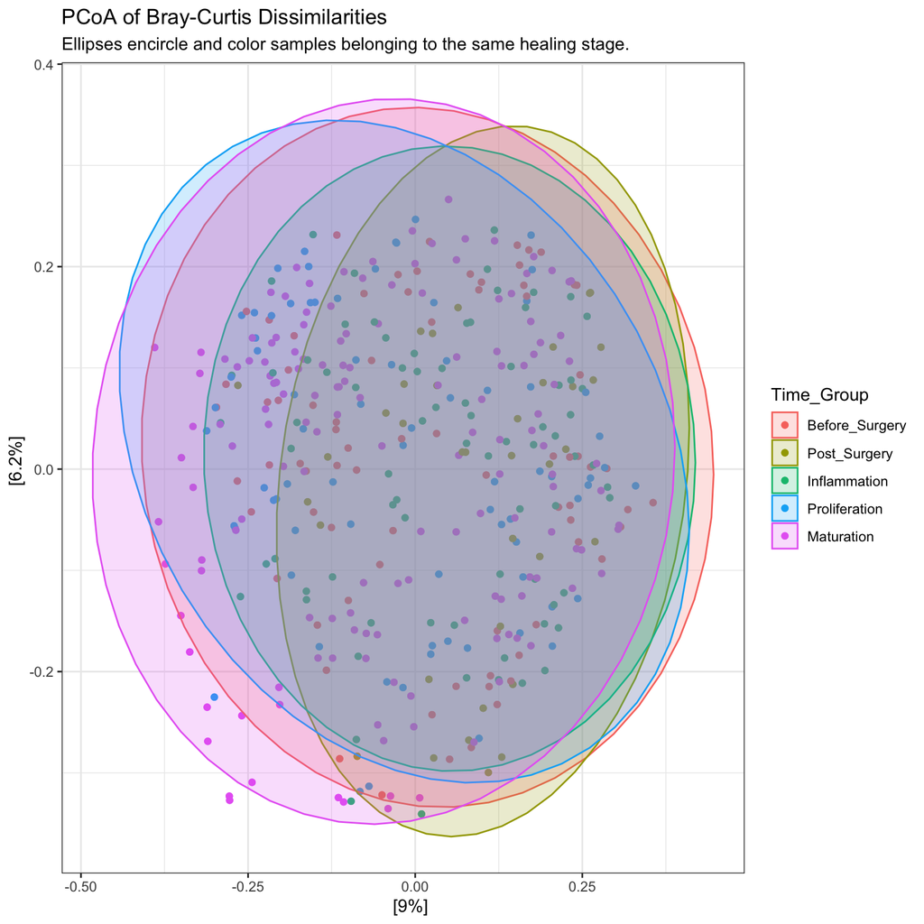

```r
# Generate bray-curtis distance matrix using ASV relative abundances
bray_dist <- phyloseq::distance(ps_rel_2, method = "bray")
bray_matrix <- as.matrix(bray_dist)

# ordinate PCoA from full bray-curtis matrix
set.seed(100)

bray_pcoa <- ordinate(ps_rel_2, method = "PCoA", distance =  bray_dist)

p1 <- plot_ordination(ps_rel_2, bray_pcoa, color = "Time_Group")


p1 + ggtitle("PCoA of Bray-Curtis Dissimilarities", subtitle = "Ellipses encircle and color samples belonging to the same healing stage.") +
  geom_point(size = 1.5) +
  theme_bw() +
  stat_ellipse(aes(fill = Time_Group, group = Time_Group), alpha = 0.2, geom = "polygon")
```

```r
scores <- bray_pcoa$vectors
pc1 <- scores[, 1]

pc1_df <- as.data.frame(pc1) %>%
  rownames_to_column("SampleID")

paired_sample_data_pc1 <- left_join(paired_sample_data, pc1_df, by = "SampleID")

# extract PCoA coordinates (axis 1) from control and surgical samples
metadata_ctrl <- paired_sample_data_pc1 %>%
  filter(Sample_Site == "Control")
metadata_ctrl_median <- metadata_ctrl %>%
  group_by(Day_Order) %>%
  summarise(median_PCOA = median(pc1, na.rm = TRUE), .groups = "drop")

metadata_surg <- paired_sample_data_pc1 %>%
  filter(Sample_Site == "Surgical")
metadata_surg_median <- metadata_surg %>%
  group_by(Day_Order) %>%
  summarise(median_PCOA = median(pc1, na.rm = TRUE), .groups = "drop")



# Run PERMANOVA on control-subset bray curtis matrix
set.seed(100)
ctrl_bray_dist <- bray_matrix[metadata_ctrl$SampleID, metadata_ctrl$SampleID]
ctrl_bray_dist_obj <- as.dist(ctrl_bray_dist)
ps_rel_2_ctrl <- ps_rel_2 %>% subset_samples(Sample_Site == "Control")

ctrl_permanova <- adonis2(
  ctrl_bray_dist_obj ~ Day_Order,
  data = metadata_ctrl,
  strata = metadata_ctrl$Dog_ID,
  permutations = 999
)

print(ctrl_permanova)
```

```
## Permutation test for adonis under reduced model
## Blocks:  strata
## Permutation: free
## Number of permutations: 999
##
## adonis2(formula = ctrl_bray_dist_obj ~ Day_Order, data = metadata_ctrl, permutations = 999, strata = metadata_ctrl$Dog_ID)
##           Df SumOfSqs      R2     F Pr(>F)
## Model     10    2.902 0.03988 0.814  0.001 ***
## Residual 196   69.869 0.96012
## Total    206   72.771 1.00000
## ---
## Signif. codes:  0 '***' 0.001 '**' 0.01 '*' 0.05 '.' 0.1 ' ' 1
```

```r
# Run pairwise - PERMANOVA on control-subset bray curtis matrix
set.seed(100)
pairwise_results_ctrl <- pairwise.adonis2(
  ctrl_bray_dist_obj ~ Day_Order,
  strata = "Dog_ID",
  data = metadata_ctrl,
  nperm = 999)

p_values <- sapply(names(pairwise_results_ctrl)[-1], function(x) {
  pairwise_results_ctrl[[x]][["Pr(>F)"]][1]
})

# Benjamini-Hochberg (BH) adjustment since we are testing multiple comparisons
p_adjusted <- p.adjust(p_values, method = "BH")

pairwise_df <- data.frame(
  Comparison = names(p_values),
  p_value    = p_values,
  p_adj      = p_adjusted,
  row.names  = NULL
)

groups <- str_split_fixed(pairwise_df$Comparison, "_vs_", 2)

pairwise_df$Group1 <- groups[, 1]
pairwise_df$Group2 <- groups[, 2]

pairwise_df <- pairwise_df[, c("Group1", "Group2", "p_value", "p_adj")]

alpha <- 0.05
pairwise_tidy_ctrl <- pairwise_df %>%
  filter(!is.na(p_adj)) %>%
  mutate(
    Significant = ifelse(p_adj <= alpha, "Yes", "No"),
    Stars = case_when(
      p_adj <= 0.001 ~ "***",
      p_adj <= 0.01  ~ "**",
      p_adj <= 0.05  ~ "*",
      p_adj <= 0.10 ~ ".",
      TRUE ~ ""
    ),
    p_adj = round(p_adj, 4) ) %>%
  arrange(p_adj)



# Filter out insignificant pairwise results

 sig_df_ctrl <- pairwise_tidy_ctrl %>%
  filter(Significant == "Yes") %>%
  mutate(
    group1 = Group1,
    group2 = Group2,
    y.position = NA_real_,
    label = Stars
  )
x_levels <- levels(factor(metadata_ctrl$Day_Order))

sig_df_ctrl <- sig_df_ctrl %>%
  mutate(
    xmin = match(group1, x_levels),
    xmax = match(group2, x_levels)
  ) %>%
  arrange(p_value) %>%
  mutate(
    y.position = max(metadata_ctrl$pc1, na.rm = TRUE) +
      seq(0.05, by = 0.05, length.out = n())
  )
print(sig_df_ctrl)
```

```
##                  Group1 Group2 p_value  p_adj Significant Stars
## 1                 Day 1 Week 5   0.001 0.0367         Yes     *
## 2 Day 0c - Post Surgery Week 5   0.002 0.0367         Yes     *
## 3                Week 2 Week 4   0.002 0.0367         Yes     *
##                  group1 group2 y.position label xmin xmax
## 1                 Day 1 Week 5  0.4059136     *    4   10
## 2 Day 0c - Post Surgery Week 5  0.4559136     *    3   10
## 3                Week 2 Week 4  0.5059136     *    7    9
```

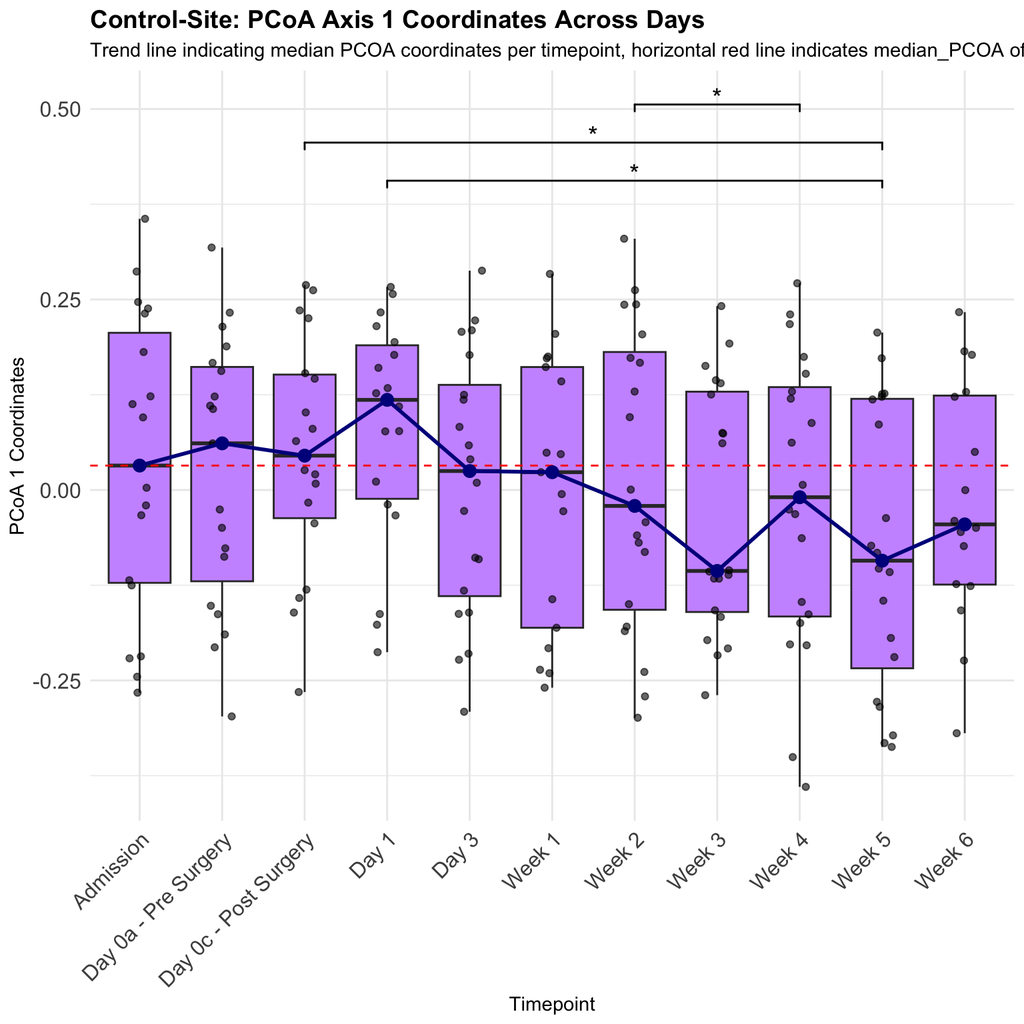

```r
ggplot(metadata_ctrl, aes(x = Day_Order, y = pc1)) +
  geom_boxplot(fill = "#CC99FF") +
  geom_jitter(width = 0.15, alpha = 0.6, color = "black") +

  geom_hline(yintercept = metadata_ctrl_median$median_PCOA[1], linetype = "dashed", color="red") +
  geom_point(data = metadata_ctrl_median, aes(x = Day_Order, y = median_PCOA),
             inherit.aes = FALSE, color = "darkblue", size = 3) +
  geom_line(data = metadata_ctrl_median, aes(x = Day_Order, y = median_PCOA, group = 1),
            inherit.aes = FALSE, color = "darkblue", linewidth = 1) +

  labs(
    title = "Control-Site: PCoA Axis 1 Coordinates Across Days",
    subtitle = "Trend line indicating median PCOA coordinates per timepoint, horizontal red line indicates median_PCOA of Admission",
    x = "Timepoint",
    y = "PCoA 1 Coordinates"
  ) +
  theme_minimal() +

  stat_pvalue_manual(
    sig_df_ctrl,
    label = "label",
    xmin = "xmin",
    xmax = "xmax",
    y.position = "y.position",
    tip.length = 0.01,
    bracket.size = 0.5,
    size = 5
  ) +
  theme(
    plot.title = element_text(size = 14, face = "bold"),
    axis.text.x = element_text(size = 12, angle = 45, hjust = 1),
    axis.text.y = element_text(size = 12)
  )
```

```r
# Surgical groups
set.seed(100)

surg_bray_dist <- bray_matrix[metadata_surg$SampleID, metadata_surg$SampleID]
surg_bray_dist_obj <- as.dist(surg_bray_dist)
ps_rel_2_surg <- ps_rel_2 %>% subset_samples(Sample_Site == "Surgical")

surg_permanova <- adonis2(
  surg_bray_dist_obj ~ Day_Order,
  data = metadata_surg,
  strata = metadata_surg$Dog_ID,
  permutations = 999
)

print(surg_permanova)
```

```
## Permutation test for adonis under reduced model
## Blocks:  strata
## Permutation: free
## Number of permutations: 999
##
## adonis2(formula = surg_bray_dist_obj ~ Day_Order, data = metadata_surg, permutations = 999, strata = metadata_surg$Dog_ID)
##           Df SumOfSqs     R2      F Pr(>F)
## Model     10    3.518 0.0485 0.9991  0.001 ***
## Residual 196   69.022 0.9515
## Total    206   72.540 1.0000
## ---
## Signif. codes:  0 '***' 0.001 '**' 0.01 '*' 0.05 '.' 0.1 ' ' 1
```

```r
### Pairwise PERMANOVA
set.seed(100)
pairwise_results_surg <- pairwise.adonis2(
  surg_bray_dist_obj ~ Day_Order,
  strata = "Dog_ID",
  data = metadata_surg,
  nperm = 999)

p_values <- sapply(names(pairwise_results_surg)[-1], function(x) {
  pairwise_results_surg[[x]][["Pr(>F)"]][1]
})

# Benjamini-Hochberg (BH) adjustment since we are testing multiple comparisons
p_adjusted <- p.adjust(p_values, method = "BH")

pairwise_df <- data.frame(
  Comparison = names(p_values),
  p_value    = p_values,
  p_adj      = p_adjusted,
  row.names  = NULL
)

groups <- str_split_fixed(pairwise_df$Comparison, "_vs_", 2)

pairwise_df$Group1 <- groups[, 1]
pairwise_df$Group2 <- groups[, 2]

pairwise_df <- pairwise_df[, c("Group1", "Group2", "p_value", "p_adj")]

alpha <- 0.05
pairwise_tidy_surg <- pairwise_df %>%
  filter(!is.na(p_adj)) %>%
  mutate(
    Significant = ifelse(p_adj <= alpha, "Yes", "No"),
    Stars = case_when(
      p_adj <= 0.001 ~ "***",
      p_adj <= 0.01  ~ "**",
      p_adj <= 0.05  ~ "*",
      p_adj <= 0.10 ~ ".",
      TRUE ~ ""
    ),
    p_adj = round(p_adj, 4) ) %>%
  arrange(p_adj)





 sig_df_surg <- pairwise_tidy_surg %>%
  filter(Significant == "Yes") %>%
  mutate(
    group1 = Group1,
    group2 = Group2,
    y.position = NA_real_,
    label = Stars
  )
x_levels <- levels(factor(metadata_surg$Day_Order))

sig_df_surg <- sig_df_surg %>%
  mutate(
    xmin = match(group1, x_levels),
    xmax = match(group2, x_levels)
  ) %>%
  arrange(p_value) %>%
  mutate(
    y.position = max(metadata_surg$pc1, na.rm = TRUE) +
      seq(0.05, by = 0.05, length.out = n())
  )
print(sig_df_surg)
```

```
##                   Group1                Group2 p_value  p_adj Significant Stars
## 1  Day 0c - Post Surgery                 Day 3   0.001 0.0183         Yes     *
## 2  Day 0c - Post Surgery                Week 2   0.001 0.0183         Yes     *
## 3  Day 0c - Post Surgery                Week 6   0.001 0.0183         Yes     *
## 4  Day 0c - Post Surgery                Week 3   0.002 0.0220         Yes     *
## 5  Day 0c - Post Surgery                Week 4   0.002 0.0220         Yes     *
## 6  Day 0c - Post Surgery                Week 1   0.004 0.0275         Yes     *
## 7                  Day 1                Week 4   0.004 0.0275         Yes     *
## 8              Admission Day 0c - Post Surgery   0.005 0.0275         Yes     *
## 9  Day 0c - Post Surgery  Day 0a - Pre Surgery   0.005 0.0275         Yes     *
## 10                 Day 1                Week 2   0.006 0.0275         Yes     *
## 11                 Day 1                Week 5   0.006 0.0275         Yes     *
## 12                 Day 1                Week 6   0.006 0.0275         Yes     *
## 13 Day 0c - Post Surgery                Week 5   0.007 0.0275         Yes     *
## 14                Week 2                Week 5   0.007 0.0275         Yes     *
```

[output cut: 23 more lines]

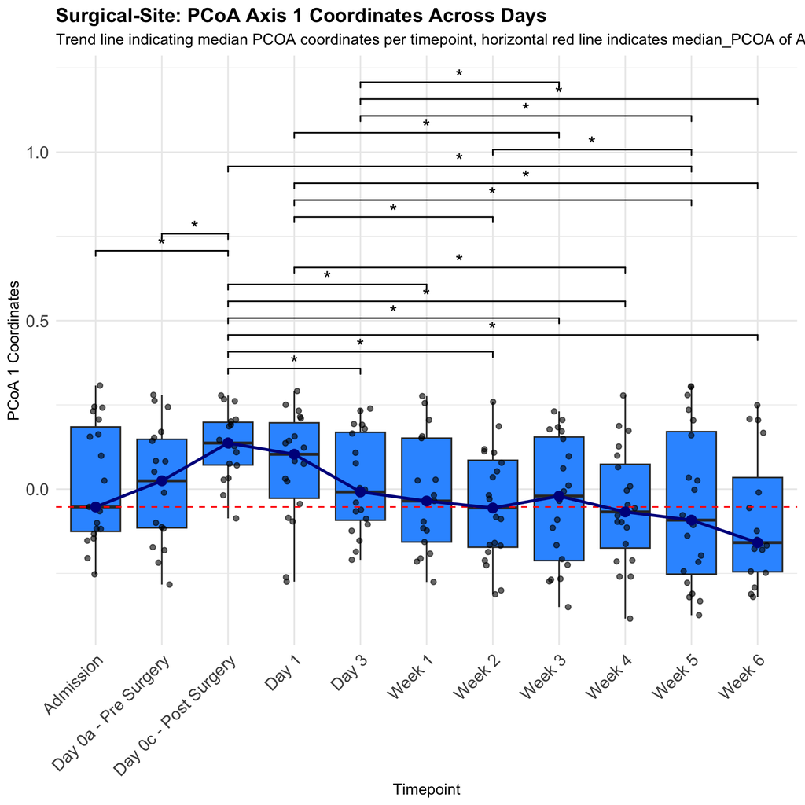

```r
ggplot(metadata_surg, aes(x = Day_Order, y = pc1)) +
  geom_boxplot(fill = "#3399FF") +
  geom_jitter(width = 0.15, alpha = 0.6, color = "black") +

  geom_hline(yintercept = metadata_surg_median$median_PCOA[1], linetype = "dashed", color="red") +
  geom_point(data = metadata_surg_median, aes(x = Day_Order, y = median_PCOA),
             inherit.aes = FALSE, color = "darkblue", size = 3) +
  geom_line(data = metadata_surg_median, aes(x = Day_Order, y = median_PCOA, group = 1),
            inherit.aes = FALSE, color = "darkblue", linewidth = 1) +

  labs(
    title = "Surgical-Site: PCoA Axis 1 Coordinates Across Days",
    subtitle = "Trend line indicating median PCOA coordinates per timepoint, horizontal red line indicates median_PCOA of Admission",
    x = "Timepoint",
    y = "PCoA 1 Coordinates"
  ) +
  theme_minimal() +

  stat_pvalue_manual(
    sig_df_surg,
    label = "label",
    xmin = "xmin",
    xmax = "xmax",
    y.position = "y.position",
    tip.length = 0.01,
    bracket.size = 0.5,
    size = 5
  ) +
  theme(
    plot.title = element_text(size = 14, face = "bold"),
    axis.text.x = element_text(size = 12, angle = 45, hjust = 1),
    axis.text.y = element_text(size = 12)
  )
```

## LMM

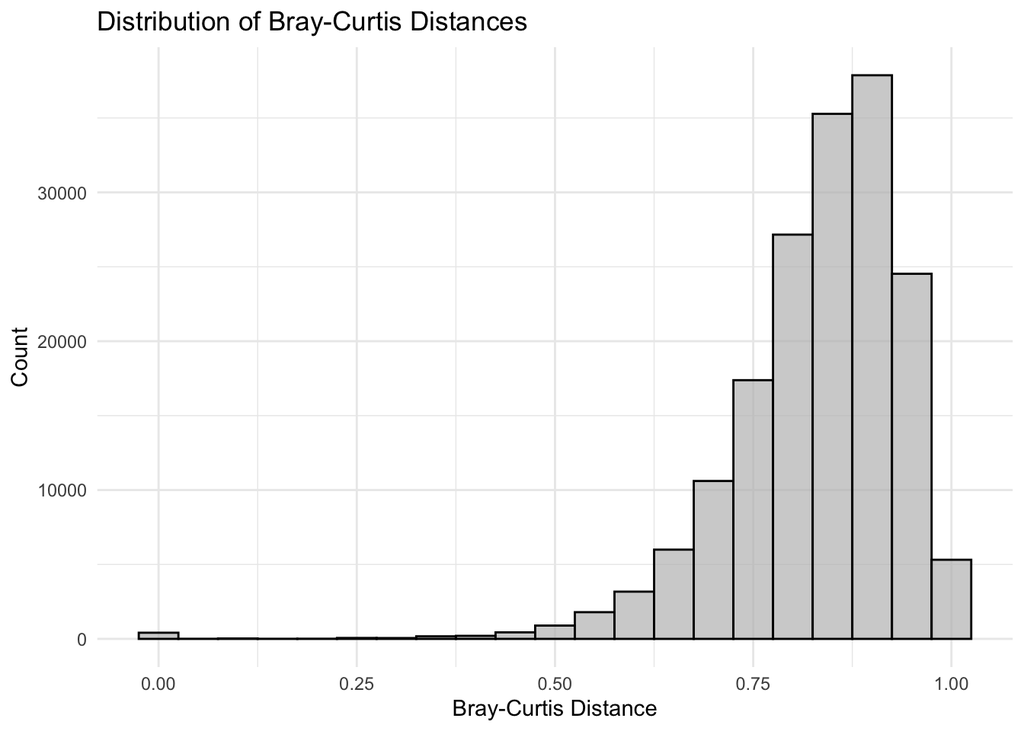

```r
### Transformation BC
eps <- 1e-8

x <- as.vector(bray_matrix)
# Plot Distribution of Transformed Bray-Curtis Distances
histogram_distances <- ggplot(data = data.frame(x), aes(x = x)) +
  geom_histogram(binwidth = 0.05, fill = "gray", color = "black", alpha = 0.7) +
  theme_minimal() +
  labs(
    title = "Distribution of Bray-Curtis Distances",
    x = "Bray-Curtis Distance",
    y = "Count"
  )

print(histogram_distances)
```

```r
transforms <- list(
  log1p     = log1p(x),
  log_eps   = log(x + eps),
  sqrt      = sqrt(x),
  sqrt1p    = sqrt(x + 1),
  arcsin_s  = asin(sqrt(x / max(x))),
  arcsin_p  = asin(sqrt(pmin(pmax(x, 0), 1)))
)

res <- data.frame(
  transformation = names(transforms),
  A = sapply(transforms, function(v) ad.test(v)$statistic),
  p = sapply(transforms, function(v) ad.test(v)$p.value)
)

res <- res[order(res$A), ]
res
```

|  | transformation | A | p |
| --- | --- | --- | --- |
| arcsin_s.A | arcsin_s | 685.3503 | 3.7e-24 |
| arcsin_p.A | arcsin_p | 693.6452 | 3.7e-24 |
| sqrt1p.A | sqrt1p | 3537.7573 | 3.7e-24 |
| log1p.A | log1p | 4344.2710 | 3.7e-24 |
| sqrt.A | sqrt | 6391.3421 | 3.7e-24 |
| log_eps.A | log_eps | 47442.7732 | 3.7e-24 |

```r
best_transform <- res$transformation[1]
best_transform
```

```
## [1] "arcsin_s"
```

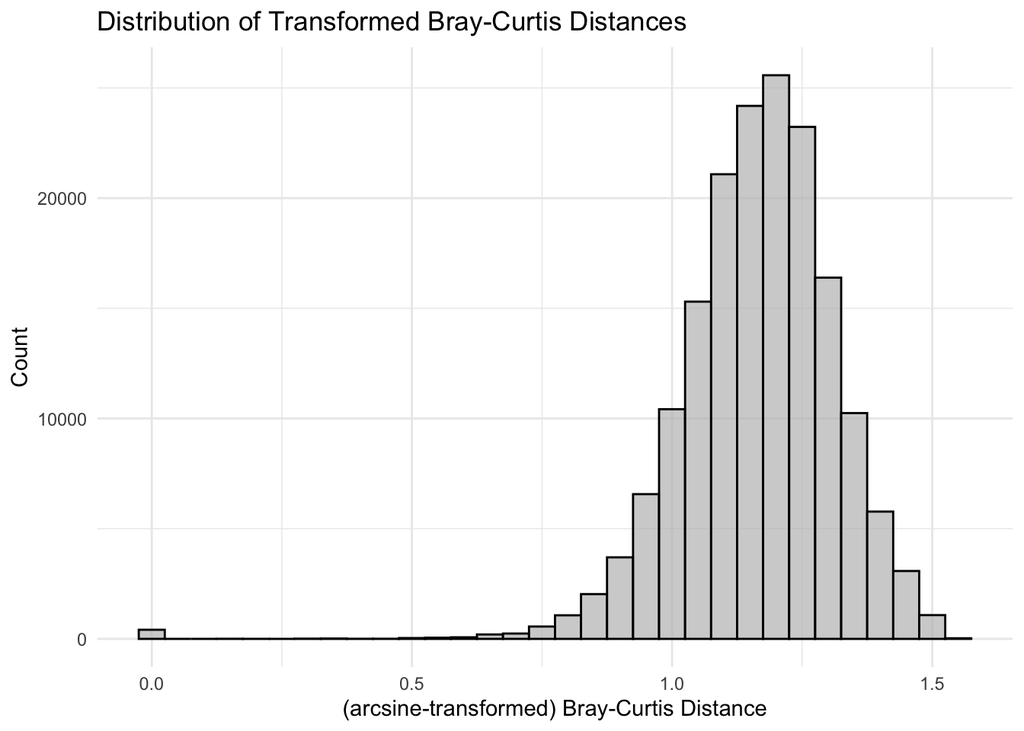

```r
bray_arcsin_s <- asin(sqrt(bray_matrix))

# get vector for histogram
bray_vec <- as.vector(bray_arcsin_s)

# Plot Distribution of Transformed Bray-Curtis Distances
histogram_distances <- ggplot(data = data.frame(bray_vec), aes(x = bray_vec)) +
  geom_histogram(binwidth = 0.05, fill = "gray", color = "black", alpha = 0.7) +
  theme_minimal() +
  labs(
    title = "Distribution of Transformed Bray-Curtis Distances",
    x = "(arcsine-transformed) Bray-Curtis Distance",
    y = "Count"
  )

print(histogram_distances)
```

### BC: Control-Surgical Paired

Model = lmer(Bray_Distance ~ Day_Order + (1 | Dog_ID)) * Contrasts between estimated marginal means of timepoints from model, using Tukey-adjusting p-values:

**Notes:** Estimated marginal means from the mixed model showed a significant increase in BC dissimilarity between control and surgical sites immediately after surgery compared with Pre-Surgery, followed by a significant decline by Weeks 3 and 5.

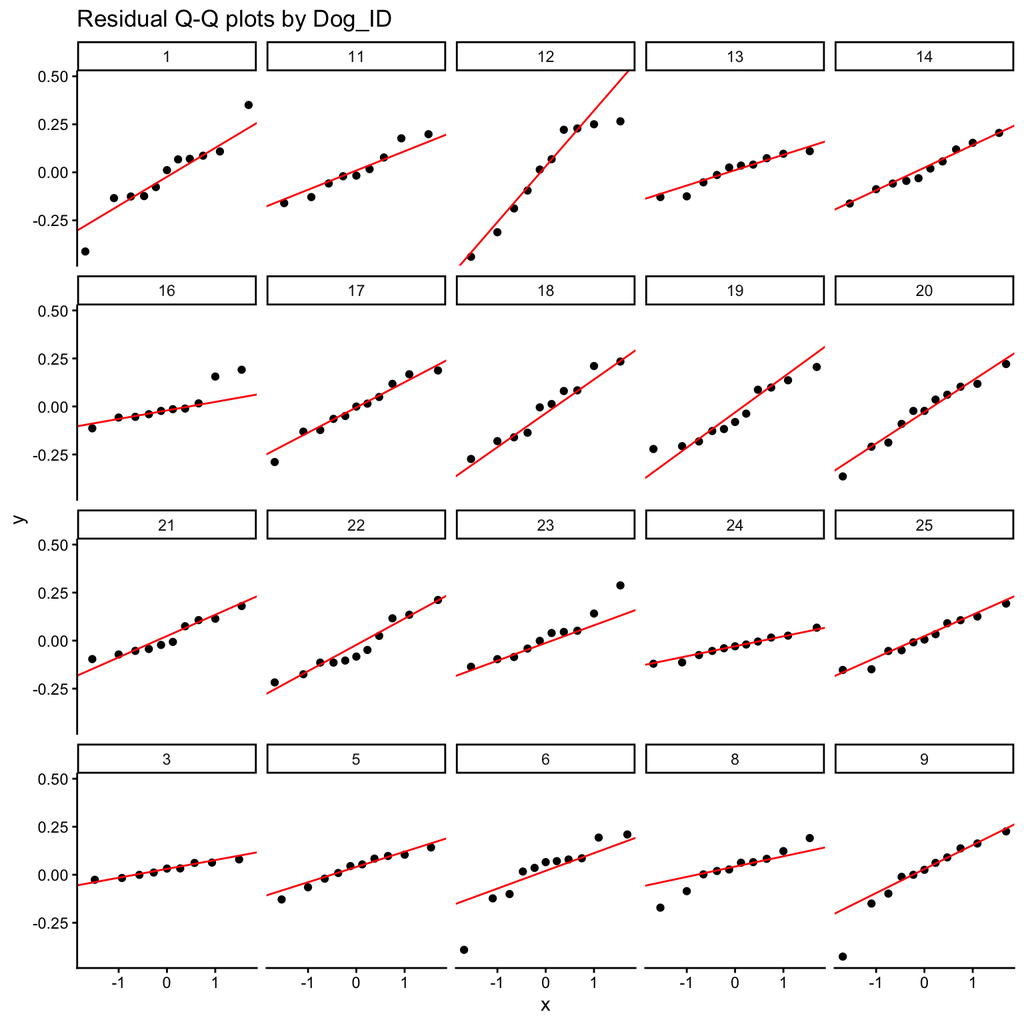

```r
# before transformation
paired_distances <- paired_sample_data %>%
 group_by(Dog_ID, Day_Order) %>%
  summarise(
    Control_Sample = SampleID[Sample_Site == "Control"][1],
    Surgical_Sample = SampleID[Sample_Site == "Surgical"][1],
    Bray_Distance = bray_matrix[Control_Sample, Surgical_Sample],
    Sample_Plate = Sample_Plate[1],
    Day_Order = Day_Order[1],
    Collection_Day = Collection_Day[1],
   .groups = "drop"
  )
lmer_bray <- lmer(
  Bray_Distance ~ Day_Order + (1 | Dog_ID),
  data = paired_distances
)
paired_distances$fitted <- fitted(lmer_bray)
paired_distances$resid <- resid(lmer_bray)
ggplot(paired_distances, aes(sample = resid)) +
  stat_qq() +
  stat_qq_line(color = "red") +
  facet_wrap(~ Dog_ID) +
  theme_classic() +
  labs(title = "Residual Q-Q plots by Dog_ID")
```

```r
bray_arcsin_s <- as.matrix(bray_arcsin_s)
# generate paired-BC matrix where control and surgical samples within dogs are measured
paired_distances <- paired_sample_data %>%
 group_by(Dog_ID, Day_Order) %>%
  summarise(
    Control_Sample = SampleID[Sample_Site == "Control"][1],
    Surgical_Sample = SampleID[Sample_Site == "Surgical"][1],
    Bray_Distance = bray_arcsin_s[Control_Sample, Surgical_Sample],
    Sample_Plate = Sample_Plate[1],
    Day_Order = Day_Order[1],
    Collection_Day = Collection_Day[1],
   .groups = "drop"
  )


print("Group means by Day_Order:")
```

```
## [1] "Group means by Day_Order:"
```

```r
print(paired_distances %>%
  group_by(Day_Order) %>%
  summarise(
    Mean_Bray = mean(Bray_Distance),
    Median_Bray = median(Bray_Distance),
    SD_Bray = sd(Bray_Distance),
    N = n(),
    .groups = "drop"  ) %>%
    arrange(Day_Order)
)
```

```
## # A tibble: 11 × 5
##    Day_Order             Mean_Bray Median_Bray SD_Bray     N
##    <chr>                     <dbl>       <dbl>   <dbl> <int>
##  1 Admission                 0.853       0.876   0.157    19
##  2 Day 0a - Pre Surgery      0.842       0.825   0.210    19
##  3 Day 0c - Post Surgery     1.01        1.02    0.181    18
##  4 Day 1                     0.910       0.900   0.180    18
##  5 Day 3                     0.901       0.910   0.135    20
##  6 Week 1                    0.857       0.882   0.151    17
##  7 Week 2                    0.902       0.914   0.150    20
##  8 Week 3                    0.853       0.911   0.188    20
##  9 Week 4                    0.887       0.899   0.212    20
## 10 Week 5                    0.854       0.901   0.166    20
## 11 Week 6                    0.883       0.861   0.170    16
```

```r
# Already grouped by dog in paired_distances
# Random effects to account for per dog replicates
lmer_bray <- lmer(
  Bray_Distance ~ Day_Order + (1 | Dog_ID),
  data = paired_distances
)

anova(lmer_bray)
```

|  | npar | Sum Sq | Mean Sq | F value |
| --- | --- | --- | --- | --- |
| Day_Order | 10 | 0.443204 | 0.0443204 | 1.813295 |

```r
summary(lmer_bray)
```

```
## Linear mixed model fit by REML ['lmerMod']
## Formula: Bray_Distance ~ Day_Order + (1 | Dog_ID)
##    Data: paired_distances
##
## REML criterion at convergence: -115.2
##
## Scaled residuals:
##     Min      1Q  Median      3Q     Max
## -3.2110 -0.6000  0.0047  0.5620  2.6871
##
## Random effects:
##  Groups   Name        Variance Std.Dev.
##  Dog_ID   (Intercept) 0.005921 0.07695
##  Residual             0.024442 0.15634
## Number of obs: 207, groups:  Dog_ID, 20
##
## Fixed effects:
##                                 Estimate Std. Error t value
## (Intercept)                     0.857612   0.039837  21.528
## Day_OrderDay 0a - Pre Surgery  -0.014802   0.050818  -0.291
## Day_OrderDay 0c - Post Surgery  0.162161   0.051575   3.144
## Day_OrderDay 1                  0.053337   0.051571   1.034
## Day_OrderDay 3                  0.043596   0.050131   0.870
## Day_OrderWeek 1                 0.005305   0.052407   0.101
## Day_OrderWeek 2                 0.044138   0.050131   0.880
## Day_OrderWeek 3                -0.004979   0.050131  -0.099
## Day_OrderWeek 4                 0.028892   0.050131   0.576
## Day_OrderWeek 5                -0.004049   0.050131  -0.081
## Day_OrderWeek 6                 0.035830   0.053321   0.672
##
## Correlation of Fixed Effects:
##                (Intr) Dy_OrdrDy0-PrS Dy_OrdrDy0c-PS Dy_OD1 Dy_OD3 Dy_OW1 Dy_OW2
## Dy_OrdrDy0-PrS -0.638
## Dy_OrdrDy0c-PS -0.629  0.493
## Day_OrdrDy1    -0.629  0.493          0.485
## Day_OrdrDy3    -0.646  0.507          0.500          0.500
## Day_OrdrWk1    -0.619  0.485          0.480          0.477  0.492
## Day_OrdrWk2    -0.646  0.507          0.500          0.500  0.514  0.492
## Day_OrdrWk3    -0.646  0.507          0.500          0.500  0.514  0.492  0.514
## Day_OrdrWk4    -0.646  0.507          0.500          0.500  0.514  0.492  0.514
## Day_OrdrWk5    -0.646  0.507          0.500          0.500  0.514  0.492  0.514
## Day_OrdrWk6    -0.608  0.477          0.469          0.469  0.483  0.464  0.483
##                Dy_OW3 Dy_OW4 Dy_OW5
## Dy_OrdrDy0-PrS
## Dy_OrdrDy0c-PS
## Day_OrdrDy1
## Day_OrdrDy3
## Day_OrdrWk1
## Day_OrdrWk2
## Day_OrdrWk3
## Day_OrdrWk4     0.514
## Day_OrdrWk5     0.514  0.514
## Day_OrdrWk6     0.483  0.483  0.483
```

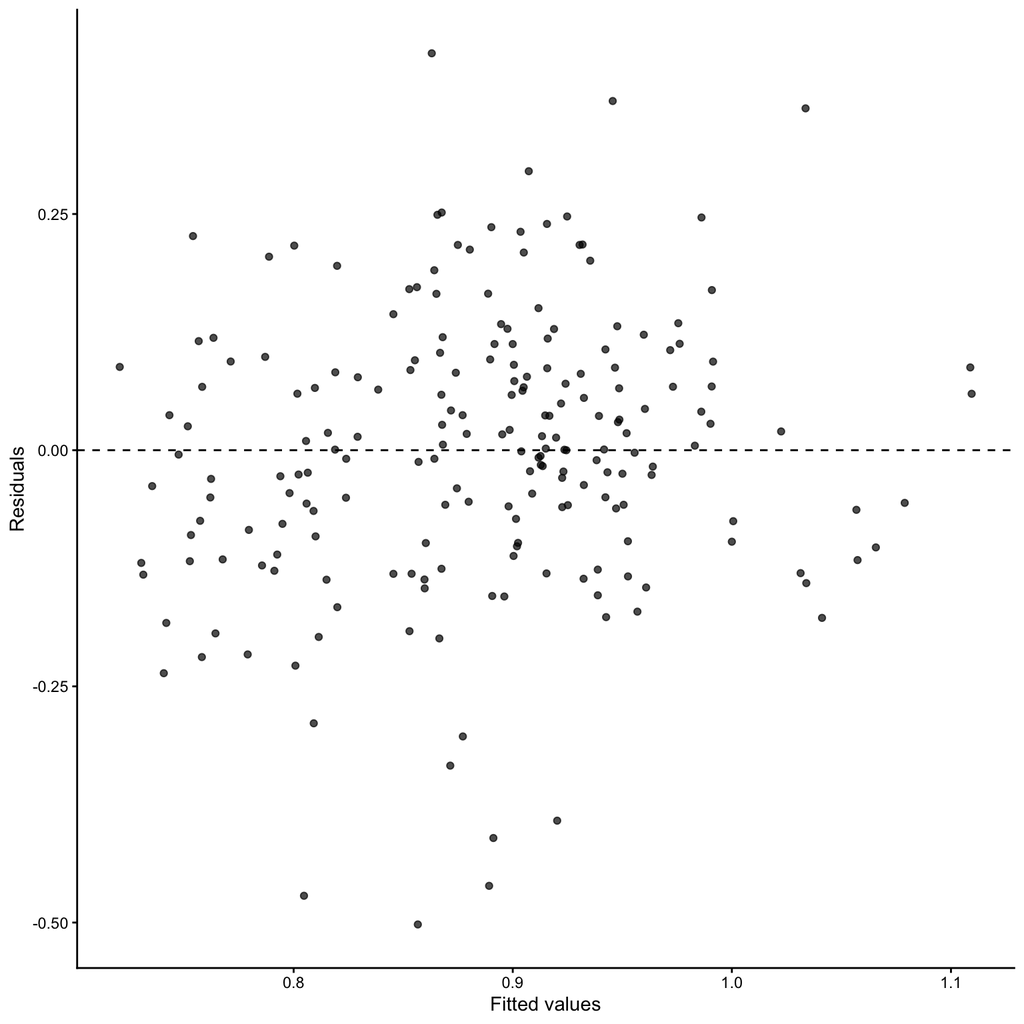

```r
paired_distances$fitted <- fitted(lmer_bray)
paired_distances$resid <- resid(lmer_bray)

# Fitted vs residuals
ggplot(paired_distances, aes(x = fitted, y = resid)) +
  geom_point(alpha = 0.7) +
  geom_hline(yintercept = 0, linetype = "dashed") +
  theme_classic() +
  labs(x = "Fitted values", y = "Residuals")
```

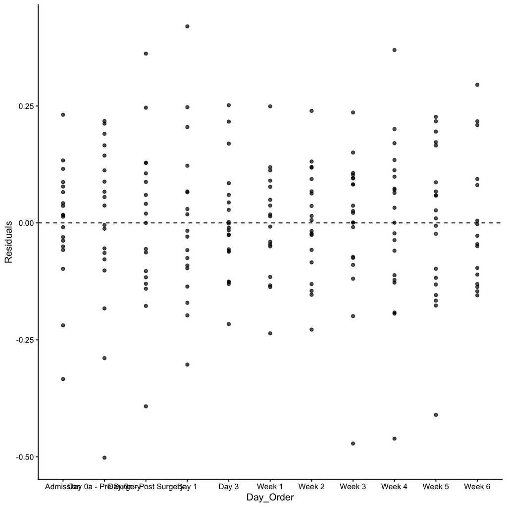

```r
# Residuals vs each independent variable
ggplot(paired_distances, aes(x = Day_Order, y = resid)) +
  geom_point(alpha = 0.7) +
  geom_smooth(se = FALSE) +
  geom_hline(yintercept = 0, linetype = "dashed") +
  theme_classic() +
  labs(x = "Day_Order", y = "Residuals")
```

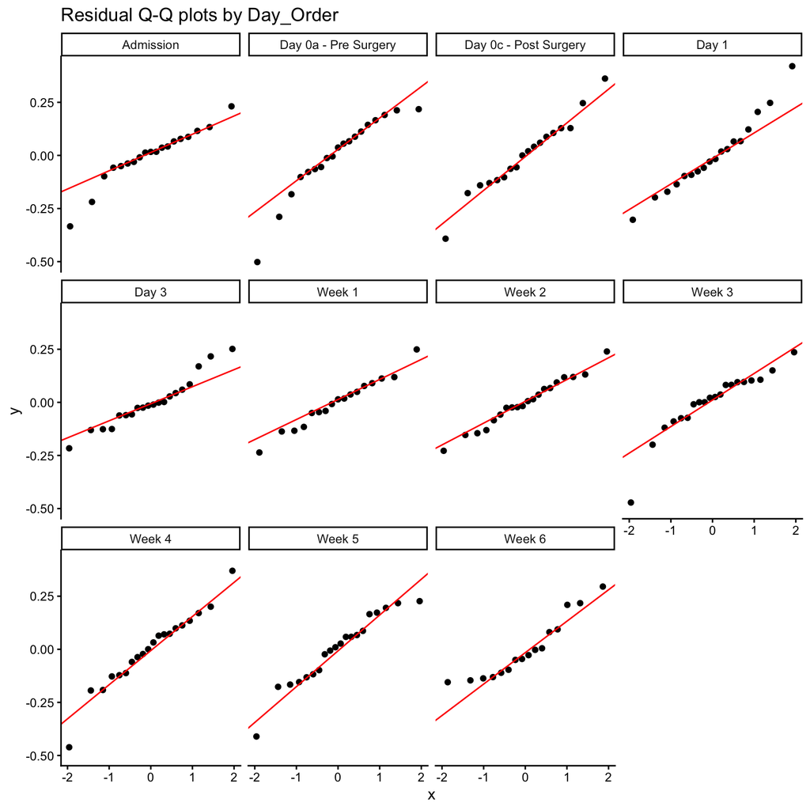

```r
ggplot(paired_distances, aes(sample = resid)) +
  stat_qq() +
  stat_qq_line(color = "red") +
  facet_wrap(~ Day_Order) +
  theme_classic() +
  labs(title = "Residual Q-Q plots by Day_Order")
```

```r
# estimated marginal means
emm <- emmeans(lmer_bray, ~ Day_Order)

emm_df <- as.data.frame(emm)[, c("Day_Order", "emmean", "SE", "df", "lower.CL", "upper.CL")]

alpha <- 0.05

contrasts <- data.frame(pairs(emm, Day_Order = "tukey"))

contrasts <- contrasts %>%
  mutate(
    Group1 = case_when(
      str_detect(contrast, "^\\(") ~ str_match(contrast, "^\\((.*?)\\)")[,2],
      TRUE ~ str_match(contrast, "^(.*?) - ")[,2]
    ),
    Group2 = case_when(
      str_detect(contrast, "\\) - \\(") ~ str_match(contrast, "- \\((.*?)\\)$")[,2],
      str_detect(contrast, "^\\(") ~ str_replace(contrast, "^\\(.*?\\) - ", ""),
      TRUE ~ str_match(contrast, "- (.*)$")[,2]
    ),
    Group1 = str_remove_all(str_trim(Group1), "[()]"),
    Group2 = str_remove_all(str_trim(Group2), "[()]")
  )

pairwise_tidy <- contrasts %>%
  filter(!is.na(p.value)) %>%
  mutate(
    Significant = ifelse(p.value <= alpha, "Yes", "No"),
    Stars = case_when(
      p.value <= 0.001 ~ "***",
      p.value <= 0.01  ~ "**",
      p.value <= 0.05  ~ "*",
      p.value <= 0.10 ~ ".",
      TRUE ~ ""
    ),
    p.value = round(p.value, 4) ) %>%
  arrange(p.value)

# Filter out insignificant pairwise results
sig_df <- pairwise_tidy %>%
  filter(Significant == "Yes") %>%
  mutate(
    group1 = Group1,
    group2 = Group2,
    y.position = NA_real_,
    label = Stars
  )
x_levels <- levels(factor(paired_distances$Day_Order))

sig_df <- sig_df %>%
  mutate(
    xmin = match(group1, x_levels),
    xmax = match(group2, x_levels)
  ) %>%
  arrange(p.value) %>%
  mutate(
    y.position = max(paired_distances$Bray_Distance, na.rm = TRUE) +
      seq(0.05, by = 0.05, length.out = n())
  )
print(sig_df)
```

```
##                                           contrast   estimate         SE
## 1 (Day 0a - Pre Surgery) - (Day 0c - Post Surgery) -0.1769626 0.05158934
## 2                 (Day 0c - Post Surgery) - Week 3  0.1671403 0.05090136
## 3                 (Day 0c - Post Surgery) - Week 5  0.1662104 0.05090136
##         df   t.ratio p.value                Group1                Group2
## 1 177.8804 -3.430217  0.0301  Day 0a - Pre Surgery Day 0c - Post Surgery
## 2 177.5869  3.283612  0.0468 Day 0c - Post Surgery                Week 3
## 3 177.5869  3.265343  0.0494 Day 0c - Post Surgery                Week 5
##   Significant Stars                group1                group2 y.position
## 1         Yes     *  Day 0a - Pre Surgery Day 0c - Post Surgery   1.445466
## 2         Yes     * Day 0c - Post Surgery                Week 3   1.495466
## 3         Yes     * Day 0c - Post Surgery                Week 5   1.545466
##   label xmin xmax
## 1     *    2    3
## 2     *    3    8
## 3     *    3   10
```

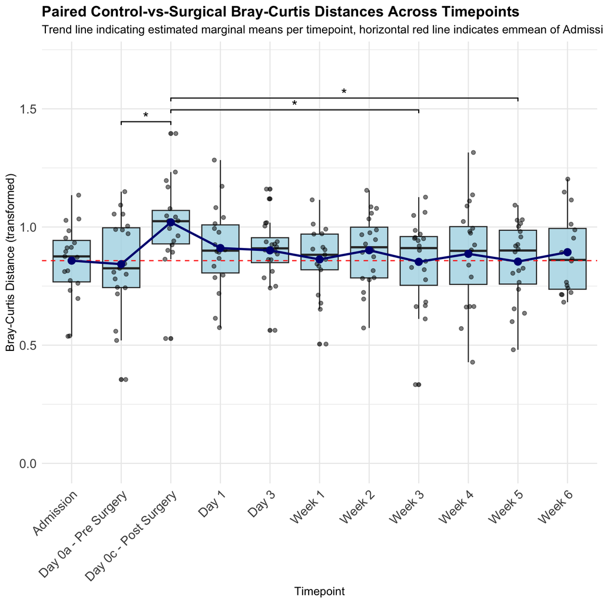

```r
ggplot(paired_distances, aes(x = Day_Order, y = Bray_Distance)) +
  coord_cartesian(ylim = c(0, 1.7)) +
  geom_boxplot(fill = "lightblue", alpha = 0.8) +
  geom_jitter(width = 0.15, alpha = 0.5, color = "black") +

  geom_hline(yintercept = emm_df$emmean[1], linetype = "dashed", color="red") +
  geom_point(data = emm_df, aes(x = Day_Order, y = emmean),
             inherit.aes = FALSE, color = "navyblue", size = 3) +
  geom_line(data = emm_df, aes(x = Day_Order, y = emmean, group = 1),
            inherit.aes = FALSE, color = "navyblue", linewidth = 1) +

  stat_pvalue_manual(
    sig_df,
    label = "label",
    xmin = "xmin",
    xmax = "xmax",
    y.position = "y.position",
    tip.length = 0.01,
    bracket.size = 0.5,
    size = 5
  ) +
  labs(
    title = "Paired Control-vs-Surgical Bray-Curtis Distances Across Timepoints",
    subtitle = "Trend line indicating estimated marginal means per timepoint, horizontal red line indicates emmean of Admission",
    x = "Timepoint",
    y = "Bray-Curtis Distance (transformed)"
  ) +
  theme_minimal() +
  theme(
    plot.title = element_text(size = 14, face = "bold"),
    axis.text.x = element_text(size = 12, angle = 45, hjust = 1),
    axis.text.y = element_text(size = 12)
  )
```